# Jun Simons - 2D Plots in matplot lib with Python

The goal of this project is to gain a good understanding of how matplot lib works to model 2 dimensional graphs.

```python
%matplotlib inline
```

```python
import matplotlib
import matplotlib.pyplot as plt
import numpy as np
from pylab import *
```

## Plotting simple figures

Using API, plot some relatively simple figures to outline the basic commands that are used.

**np.linspace()** is used to return evenly spaced numbers over a user provided interval.  
Parameters: interval range start, interval range stop, num of samples. The rest of the parameters can be found here: https://numpy.org/doc/stable/reference/generated/numpy.linspace.html

```python
x1 = np.linspace(0,5,10)
y1 = x**2 #generate some y values to plot!  This can be any function.
```

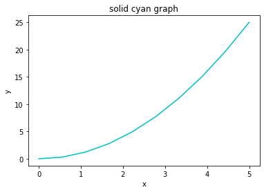

```python
figure()
plot(x1,y1,'c') #third parameter is the color
xlabel('x')
ylabel('y')
title('solid cyan graph')
show()
```

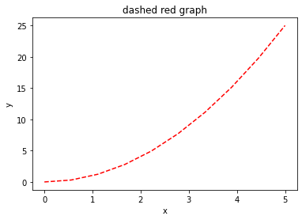

```python
figure()
plot(x,y,'--r') #this time with a different color and a dashed line
xlabel('x')
ylabel('y')
title('dashed red graph')
show()
```

## Multiple plots

**subplot** method creates two subplots in this example

The second graph is inverted when the plot is created.

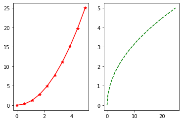

```python
subplot(1,2,1)
plot(x1,y1,'r*-') # red line with stars
subplot(1,2,2)
plot(y1,x1,'g--') # dotted green
```

## Object Oriented API

### Here is an example using 4 subplots and new X and Y data

In this case we create objects and call the respective methods on each object of the graphs. This keeps things logical and organized when creating graphs.

```python
x2 = np.linspace(0, 2 * np.pi, 400)
y2 = np.sin(x2**2) ##generate y data based on y=sin(x^2)
```

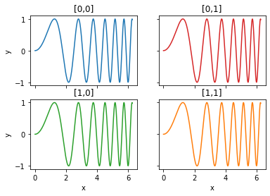

```python
fig,axs = plt.subplots(2,2) ## 2 by 2 array of graphs (so we have 4 in total)
axs[0,0].plot(x2,y2)
axs[0,0].set_title('[0,0]')
axs[0,1].plot(x2,y2,'tab:red')
axs[0,1].set_title('[0,1]')
axs[1,0].plot(x2,y2,'tab:green')
axs[1,0].set_title('[1,0]')
axs[1,1].plot(x2,y2,'tab:orange')
axs[1,1].set_title('[1,1]')

for ax in axs.flat:
    ax.set(xlabel = 'x', ylabel = 'y')

for ax in axs.flat:
    ax.label_outer()
```

## Sharing Axes with vertical subplots

To stay organized we can make multiple subplots that all use the same axes.

In this example, we will modify the three sine graphs when we plot them and display them over the same x axis.

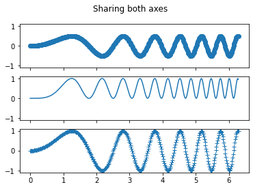

```python
fig,axs = plt.subplots(3,sharex=True,sharey=True) # creating 3 plots in an array, sharing axes
fig.suptitle('Sharing both axes')
axs[0].plot(x2, 0.5*y2, 'o')
axs[1].plot(x2, y2**2)
axs[2].plot(x2, y2, '+')
```

## More cool uses of OOP matplotlib

Since we can adjust the placement of graphs, lets try placing one graph inside another.  
The inner graph will use our second data set of sine functions and the outer graph will be the first data set, the curve.

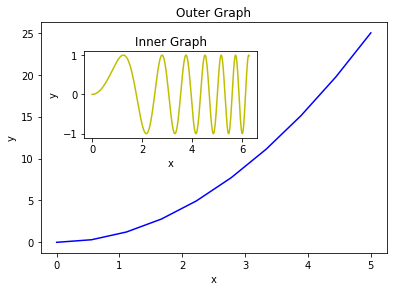

```python
fig=plt.figure()
# adjust spacing of the graphs
ax1 = fig.add_axes([0.1, 0.1, 0.8, 0.8])
ax2 = fig.add_axes([0.2, 0.5, 0.4, 0.3])

#outer graph

ax1.plot(x,y,'b')
ax1.set_xlabel('x')
ax1.set_ylabel('y')
ax1.set_title('Outer Graph')

#inner graph

ax2.plot(x2,y2,'y')
ax2.set_xlabel('x')
ax2.set_ylabel('y')
ax2.set_title('Inner Graph')
```

## Decorative Elements in Graphs

**Title**: ax.set_title()  
**Axis Labels**: ax.set_xlabel() or ax.set_ylabel()  
**Legends**: ax.legend(["1","2","3"]) and ax.legend(loc=2)

A better way to set legends is to use the "label" argument when using the plot() method.

**Symbols**: To do cool things with text, we can use **LaTex**. Put dollar signs around the text and an r before the string as demonstrated in the example below.

**Fonts**: Font size can be adjusted with the fontsize parameter, or you can alternativley change the entire configuration parameters for matplot lib using the following format:  
matplotlib.rcParams.update({'font.size': 18, 'font.family': 'serif'})

More line and marker styles can be found here: https://matplotlib.org/3.3.2/api/_as_gen/matplotlib.pyplot.plot.html

**Here is an example of some of these elements**

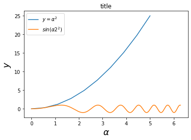

```python
fig,ax = plt.subplots()

ax.plot(x,x**2,label=r"$y = \alpha^2$")
ax.plot(x2,np.sin(x2**2),label=r"$sin(\alpha2^2)$")
ax.legend(loc=2);
ax.set_xlabel(r'$\alpha$',fontsize = 18)
ax.set_ylabel(r'$y$',fontsize = 18)
ax.set_title('title')
```

## Log scale

When graphing it is often to use a logarithmic scale for axes. We can do this by using the set_xscale and set_yscale parameters, setting the scaling type to "log".

In the example below, the y axis uses a log scale to display an exponential graph:

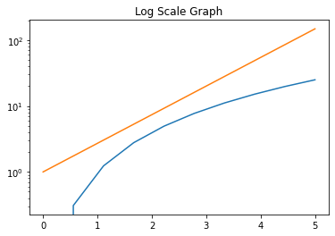

```python
fig,ax = plt.subplots()
ax.plot(x,x**2,x,np.exp(x))
ax.set_title("Log Scale Graph")
ax.set_yscale("log")
```

## Grid overlay

A Grid lining up with the axes can be useful to visualize data. The grid method can be called on an axes object and set to true to turn on grid lines.

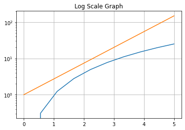

```python
fig,ax = plt.subplots()
ax.plot(x,x**2,x,np.exp(x))
ax.set_title("Log Scale Graph")
ax.set_yscale("log")
ax.grid(True) # turn on grid
```